# Uber Ride Request Analysis – Identifying Peak Hour Failures

# Project Type - Exploratory Data Analysis.

# Contribution- Individual.

# Project Summary- Uber Request Data – Exploratory Data Analysis.

This project aims to analyze Uber ride request data to identify operational inefficiencies affecting ride fulfillment. The dataset contains trip-level details, including request timestamps, pickup locations, and trip statuses such as "Completed," "Cancelled," and "No Cars Available." Through exploratory data analysis, we examined trends across time slots, pickup points, and ride statuses to uncover patterns behind trip failures.

To address these issues, the project recommends dynamic driver allocation, time-based incentives, and predictive scheduling. By implementing these data-driven strategies, Uber can improve ride fulfillment rates, enhance customer satisfaction, and drive higher operational efficiency.

This EDA not only identifies key problem areas but also provides actionable insights to support better decision-making for Uber’s service optimization.

# Github Link-

https://github.com/musk20031711/Labmentix-Projects.git

# Problem Statement-

Uber is facing frequent ride cancellations and driver unavailability, especially during certain times of the day. This project aims to explore patterns in Uber ride request data to uncover what times, locations, and statuses lead to maximum ride failures.

# Business Objective-

1.Identify operational inefficiencies in the Uber ride request system.

2.Analyze patterns by time, location, and ride status.

3.Suggest strategies to improve ride fulfillment and reduce cancellations or unavailability.

# 1. Import Libraries-

```python
import pandas as pd
import numpy as np
import matplotlib.pyplot as plt
import seaborn as sns
%matplotlib inline
```

# 2. Load Data-

```python
df = pd.read_csv("Uber.csv")
df.head()
```

|  | Request id | Pickup point | Driver id | Status | Request timestamp | Request Date | Request Time | Drop timestamp | Drop Date | Drop Time | Trip Duration (min) | Hour of Day | Day of Week |
| --- | --- | --- | --- | --- | --- | --- | --- | --- | --- | --- | --- | --- | --- |
| 0 | 619 | Airport | 1.0 | Trip Completed | 11-07-2016 11:51 | 11-07-2016 | 11:51 AM | 11-07-2016 13:00 | 11-07-2016 | 1:00 PM | 00:00 | 11 | Monday |
| 1 | 867 | Airport | 1.0 | Trip Completed | 11-07-2016 17:57 | 11-07-2016 | 5:57 PM | 11-07-2016 18:47 | 11-07-2016 | 6:47 PM | 00:00 | 17 | Monday |
| 2 | 1807 | City | 1.0 | Trip Completed | 12-07-2016 09:17 | 12-07-2016 | 9:17 AM | 12-07-2016 09:58 | 12-07-2016 | 9:58 AM | 00:00 | 9 | Tuesday |
| 3 | 2532 | Airport | 1.0 | Trip Completed | 12-07-2016 21:08 | 12-07-2016 | 9:08 PM | 12-07-2016 22:03 | 12-07-2016 | 10:03 PM | 00:00 | 21 | Tuesday |
| 4 | 3112 | City | 1.0 | Trip Completed | 13-07-2016 08:33 | 13-07-2016 | 8:33 AM | 13-07-2016 09:25 | 13-07-2016 | 9:25 AM | 24:00 | 8 | Wednesday |

# 3. Check For-

```python
df.info()
```

```
<class 'pandas.core.frame.DataFrame'>
RangeIndex: 6745 entries, 0 to 6744
Data columns (total 13 columns):
 #   Column               Non-Null Count  Dtype
---  ------               --------------  -----
 0   Request id           6745 non-null   int64
 1   Pickup point         6745 non-null   object
 2   Driver id            4095 non-null   float64
 3   Status               6745 non-null   object
 4   Request timestamp    6745 non-null   object
 5   Request Date         6745 non-null   object
 6   Request Time         6745 non-null   object
 7   Drop timestamp       2831 non-null   object
 8   Drop Date            6745 non-null   object
 9   Drop Time            6745 non-null   object
 10  Trip Duration (min)  6745 non-null   object
 11  Hour of Day          6745 non-null   int64
 12   Day of Week         6745 non-null   object
dtypes: float64(1), int64(2), object(10)
memory usage: 685.2+ KB
```

```python
df.describe()
```

|  | Request id | Driver id | Hour of Day |
| --- | --- | --- | --- |
| count | 6745.000000 | 4095.000000 | 6745.000000 |
| mean | 3384.644922 | 149.501343 | 12.956709 |
| std | 1955.099667 | 86.051994 | 6.504052 |
| min | 1.000000 | 1.000000 | 0.000000 |
| 25% | 1691.000000 | 75.000000 | 7.000000 |
| 50% | 3387.000000 | 149.000000 | 13.000000 |
| 75% | 5080.000000 | 224.000000 | 19.000000 |
| max | 6766.000000 | 300.000000 | 23.000000 |

Missing Values-

```python
df.isnull().sum()
```

```
Request id                0
Pickup point              0
Driver id              2650
Status                    0
Request timestamp         0
Request Date              0
Request Time              0
Drop timestamp         3914
Drop Date                 0
Drop Time                 0
Trip Duration (min)       0
Hour of Day               0
 Day of Week              0
dtype: int64
```

Duplicates Entries-

```python
df.duplicated().sum()
```

```
0
```

# 4. DATA CLEANING & FEATURE ENGINEERING

```python
# Convert request and drop timestamps to datetime
df['Request timestamp'] = pd.to_datetime(df['Request timestamp'], dayfirst=True)
df['Drop timestamp'] = pd.to_datetime(df['Drop timestamp'], dayfirst=True)
```

```python
# Extract useful time features
df['Request hour'] = df['Request timestamp'].dt.hour
df['Request day'] = df['Request timestamp'].dt.day_name()
```

```python
# Categorize time slots
def get_time_slot(hour):
    if 4 <= hour < 10:
        return 'Morning Rush'
    elif 10 <= hour < 17:
        return 'Day Time'
    elif 17 <= hour < 22:
        return 'Evening Rush'
    else:
        return 'Late Night'

df['Time Slot'] = df['Request hour'].apply(get_time_slot)
```

# 5. UNIVARIATE ANALYSIS-

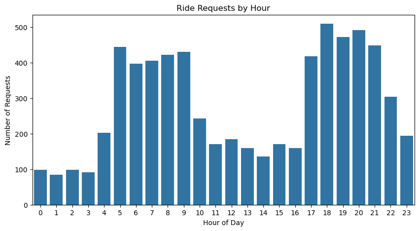

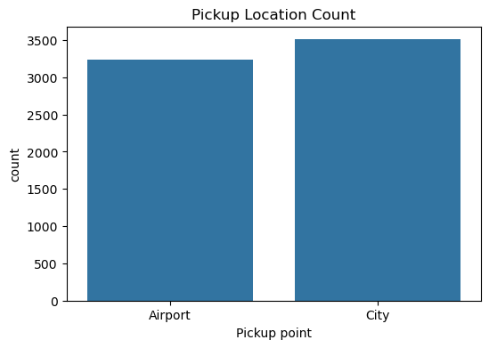

```python
plt.figure(figsize=(10,5))
sns.countplot(x='Request hour', data=df)
plt.title('Ride Requests by Hour')
plt.xlabel('Hour of Day')
plt.ylabel('Number of Requests')
plt.show()

plt.figure(figsize=(6,4))
sns.countplot(x='Pickup point', data=df)
plt.title('Pickup Location Count')
plt.show()
```

# 6. BIVARIATE ANALYSIS-

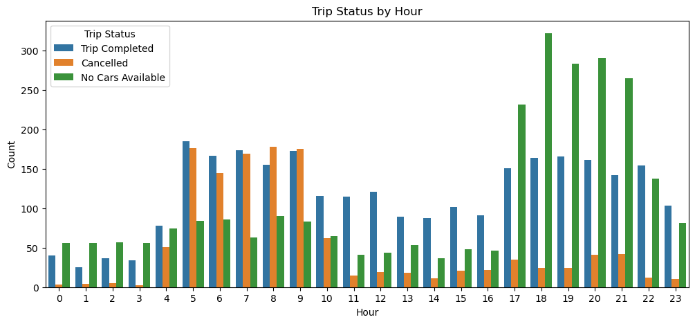

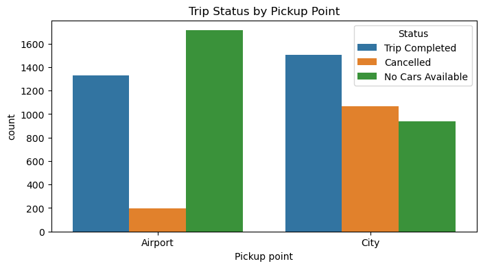

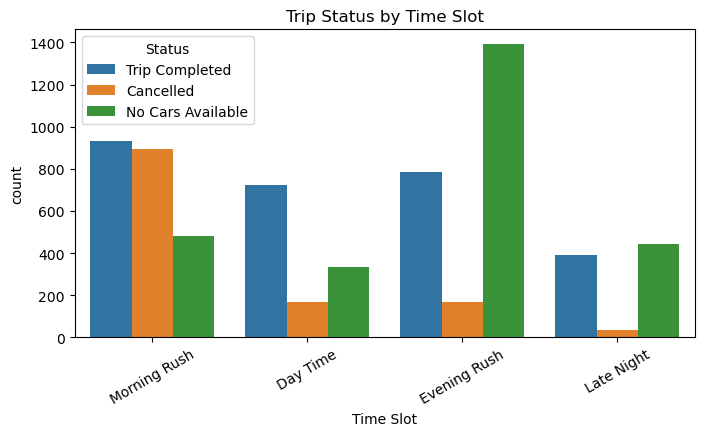

```python
plt.figure(figsize=(12,5))
sns.countplot(x='Request hour', hue='Status', data=df)
plt.title('Trip Status by Hour')
plt.xlabel('Hour')
plt.ylabel('Count')
plt.legend(title='Trip Status')
plt.show()

plt.figure(figsize=(8,4))
sns.countplot(x='Pickup point', hue='Status', data=df)
plt.title('Trip Status by Pickup Point')
plt.show()

plt.figure(figsize=(8,4))
sns.countplot(x='Time Slot', hue='Status', data=df, order=['Morning Rush', 'Day Time', 'Evening Rush', 'Late Night'])
plt.title('Trip Status by Time Slot')
plt.xticks(rotation=30)
plt.show()
```